# ECN 301E Lab #3

Let's start with setting the global path:

```stata
global path "E:\Users\Buğra\Google Drive\TA\ECN 301E\Fall '18\Labs" /* change to whatever makes you happy */
```

Import the [dataset](https://drive.google.com/open?id=10J-DEAs3d1uewYX6aQuh-lnXxZLi5Pya):

```stata
use "$path\Lab 3\data-exercise-03-bhps.dta", clear
```

## Looking at the Data

```stata
describe
```

```
Contains data from E:\Users\Buğra\Google Drive\TA\ECN 301E\Fall '18\Labs\Lab 3\data-exercise-03-bhps.dta
  obs:        12,114
 vars:            14                          19 Oct 2004 12:45
 size:       339,192
---------------------------------------------------------------------------------------------------------------------------------------------------------------------------------------------------------------------------------------------------------------
              storage   display    value
variable name   type    format     label      variable label
---------------------------------------------------------------------------------------------------------------------------------------------------------------------------------------------------------------------------------------------------------------
pno             byte    %8.0g                 person number
sex             byte    %8.0g      ksex       sex
age             byte    %8.0g      kage       age at date of interview
qfedhi          byte    %8.0g      kqfedhi    highest educational qualification
qfvoc           byte    %8.0g      kqfvoc     has vocational qualifications
jbseg           byte    %8.0g      kjbseg     socio economic group: present job
jbsect          byte    %8.0g      kjbsect    employing organisation: current job
tuknpl          byte    %8.0g      ktujbpl    union or staff association at workplace
jbsize          byte    %8.0g      kjbsize    no. employed at workplace: current job
jbhrs           byte    %8.0g      kjbhrs     no. of hours normally worked per week
jbft            byte    %8.0g      kjbft      employed full time
paygu           double  %10.0g     kpaygu     usual gross pay per month: current job
fihhmn          double  %10.0g     kfihhmn    household income: month before interview
region          byte    %8.0g      kregion    region / metropolitan area
---------------------------------------------------------------------------------------------------------------------------------------------------------------------------------------------------------------------------------------------------------------
Sorted by:
```

```stata
summarize
```

```
    Variable |        Obs        Mean    Std. Dev.       Min        Max
-------------+---------------------------------------------------------
         pno |     12,114    1.603104    .7833888          1          8
         sex |     12,114    1.515602    .4997772          1          2
         age |     12,114    38.86041    10.37946         21         60
      qfedhi |     12,114    5.711738    3.071849          1         12
       qfvoc |     12,114    .4280997    .4948238          0          1
-------------+---------------------------------------------------------
       jbseg |     12,114    8.420175    3.568408          2         19
      jbsect |     12,114    1.847945    1.425665          1          8
      tuknpl |     12,114     1.48283    .4997257          1          2
      jbsize |     12,114    5.093033    2.458105          1         11
       jbhrs |     12,114    34.87973    10.12168          2         99
-------------+---------------------------------------------------------
        jbft |     12,114    1.180617    .3847168          1          2
       paygu |     12,114    1439.047     999.231   36.83333   36027.71
      fihhmn |     12,114    3011.669    1642.871   168.4565   37549.31
      region |     12,114    11.10484    6.300484          1         19
```

**How many individuals are there in the dataset?**

The first column of the table above gives us the number of observations (individuals in this case). So the answer is $12114$.

**What proportion of the sample are women?**

```stata
tab sex
```

```
                   sex  |      Freq.     Percent        Cum.
------------------------+-----------------------------------
                male    |      5,868       48.44       48.44
                female  |      6,246       51.56      100.00
------------------------+-----------------------------------
                  Total |     12,114      100.00
```

$51.56\%$ of the sample are women.

**What is the maximum number of hours worked in a week?**

```stata
sum jbhrs
```

```
    Variable |        Obs        Mean    Std. Dev.       Min        Max
-------------+---------------------------------------------------------
       jbhrs |     12,114    34.87973    10.12168          2         99
```

The answer is $99$.

**What is average monthly earnings?**

```stata
sum paygu
```

```
    Variable |        Obs        Mean    Std. Dev.       Min        Max
-------------+---------------------------------------------------------
       paygu |     12,114    1439.047     999.231   36.83333   36027.71
```

The answer is $\$1439.047$.

**What proportion of the sample work part-time?**

```stata
tab jbft
```

```
   employed full time   |      Freq.     Percent        Cum.
------------------------+-----------------------------------
full time: 30 hrs +     |      9,926       81.94       81.94
part time: lt 30 hrs    |      2,188       18.06      100.00
------------------------+-----------------------------------
                  Total |     12,114      100.00
```

$81.94\%$ of the sample work full time.

## Generating Hourly Wages

The dataset does not have an hourly wage variable, but has information on usual hours worked per week (`jbhrs`) and usual monthly pay (`paygu`).

You will need to generate an hourly wage variable. One way is to calculate hours per month $(=$ `jbhrs` $\times52)/12)$ and then divide the monthly pay variable by hours per month.

**Generate an hourly wage variable**

```stata
gen hrs_per_month = 52*jbhrs/12
lab var hrs_per_month "Hours Worked Per Month"
gen hourwage = paygu / hrs_per_month
lab var hourwage "Hourly Wage"
```

**What is the mean and median hourly wage?**

```stata
sum hourwage, detail
```

```
                         Hourly Wage
-------------------------------------------------------------
      Percentiles      Smallest
 1%     2.857143       .5617627
 5%     3.941177       .6123047
10%     4.491936       .6770281       Obs              12,114
25%     5.777778       .7142857       Sum of Wgt.      12,114

50%     7.984413                      Mean           9.355841
                        Largest       Std. Dev.      5.822312
75%     11.25866       80.00001
90%     15.60452       101.9215       Variance       33.89931
95%     19.23077       103.3183       Skewness       6.013283
99%     29.96068       207.8522       Kurtosis       134.7554
```

Mean and median hourly wage are $\$9.355841$ and $\$7.984413$ respectively.

One way to look at the distribution of hourly wages is to graph it. To do this type:

```
(bin=40, start=.56176269, width=5.182261)
```

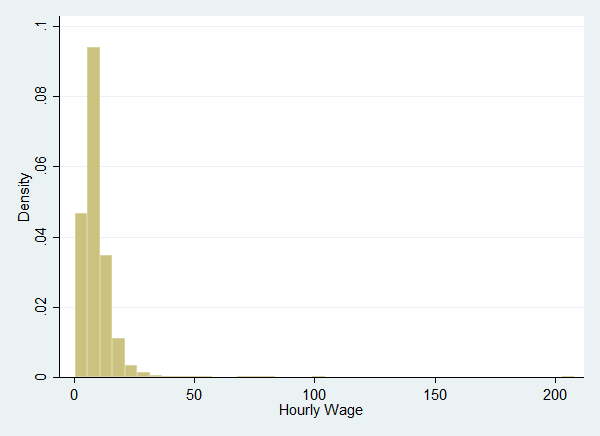

```stata
histogram hourwage
```

```
(bin=40, start=.56176269, width=.73497289)
```

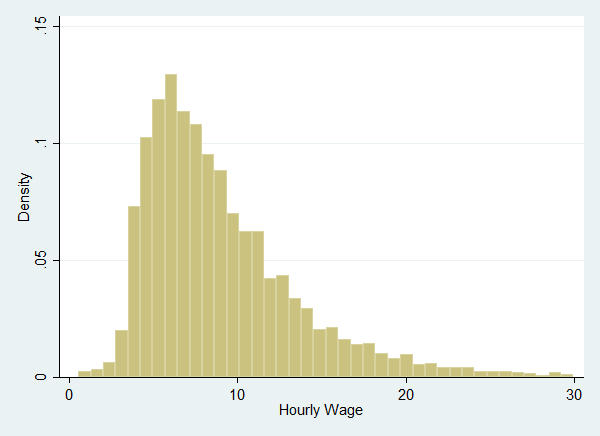

```stata
histogram hourwage if hourwage < 30
```

You can overlay a normal distribution to see how it compares:

```
(bin=40, start=.56176269, width=.73497289)
```

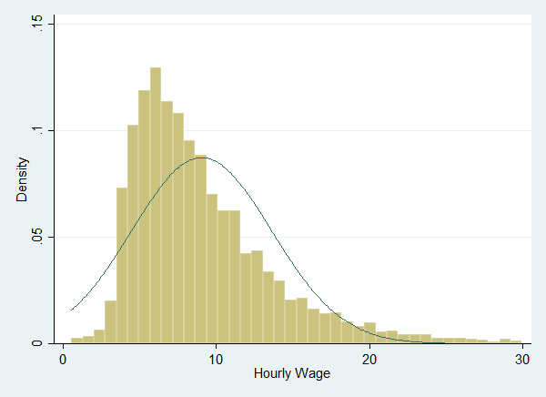

```stata
histogram hourwage, normal, if hourwage < 30
```

During the period of the survey, the minimum wage was $£3.60$ an hour. To look at where this lies on the distribution, you can draw a vertical line at $£3.60$ by typing:

```
(bin=40, start=.56176269, width=.73497289)
```

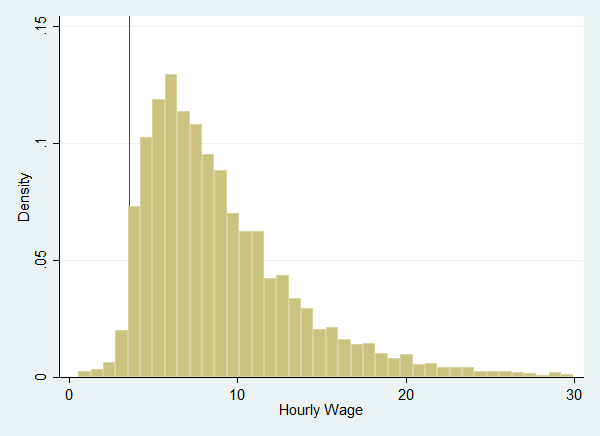

```stata
histogram hourwage if hourwage < 30, xline(3.6)
```

Using the command `tabulate varname, su(hourwage)`, look at how average wages vary by sex, region, full-time/part-time, occupation (socio-economic group), size of workplace, whether there is a union, education.

```stata
tabulate sex, su(hourwage)
```

```
            |       Summary of Hourly Wage
       sex  |        Mean   Std. Dev.       Freq.
------------+------------------------------------
    male    |   10.691937   6.5630808       5,868
    female  |   8.1006038   4.6938359       6,246
------------+------------------------------------
      Total |   9.3558411   5.8223116      12,114
```

```stata
tabulate region, su(hourwage)
```

```
   region / |
metropolita |       Summary of Hourly Wage
   n area   |        Mean   Std. Dev.       Freq.
------------+------------------------------------
  inner lon |   12.549038   7.5522485         214
  outer lon |   11.648977   7.1582453         537
  r. of sou |    10.46993   6.0670207       1,665
  south wes |   8.9857779   5.1489152         774
  east angl |   8.7309914   6.0463289         326
  east midl |   8.5162409   5.4545818         780
  west midl |   8.5295824   5.4505141         280
  r. of wes |   9.5143693   6.1102379         490
  greater m |   10.048735   7.1311727         342
  merseysid |   9.2675727   5.6917683         163
  r. of nor |   9.0839761   4.9889955         388
  south yor |   8.4174623   3.4302221         210
  west york |   8.9303226   5.4057243         261
  r. of yor |   8.4252163    4.187537         271
  tyne & we |    8.605968   4.7267715         192
  r. of nor |   8.6206266   4.3602151         353
      wales |   8.6403007   6.2826771       2,005
   scotland |   9.2849888   5.3205478       2,738
  northern  |   9.3906768   4.9581494         125
------------+------------------------------------
      Total |   9.3558411   5.8223116      12,114
```

```stata
tabulate jbft, su(hourwage)
```

```
   employed |       Summary of Hourly Wage
full time   |        Mean   Std. Dev.       Freq.
------------+------------------------------------
  full time |   9.8235129   5.8091205       9,926
  part time |   7.2342182   5.3958406       2,188
------------+------------------------------------
      Total |   9.3558411   5.8223116      12,114
```

```stata
tabulate jbseg, su(hourwage)
```

```
      socio |
   economic |
     group: |       Summary of Hourly Wage
present job |        Mean   Std. Dev.       Freq.
------------+------------------------------------
  managers, |   14.404615    7.397039       1,455
  managers, |   10.849518   8.9719349         872
  professio |   14.661699   6.5044327         601
  int. non- |   10.863556   5.2513028       1,809
  int. non- |   8.4225719   3.3975892         527
  junior no |   7.3460206   4.1123312       2,578
  personal  |   5.6625741   2.5018889         686
  foreman m |   8.6502432    3.503737         625
  skilled m |   8.4479854   3.3365317       1,231
  semi-skil |   6.9068794   3.0603629       1,168
  unskilled |   5.7087408   2.4738034         472
  farmers - |   8.8287817   3.4509735           7
  agricultu |   6.0825103   2.7622071          71
  members o |   10.896275   5.2643162          12
------------+------------------------------------
      Total |   9.3558411   5.8223116      12,114
```

```stata
tabulate jbsize, su(hourwage)
```

```
        no. |
employed at |
 workplace: |       Summary of Hourly Wage
current job |        Mean   Std. Dev.       Freq.
------------+------------------------------------
    1 - 2   |    7.743676   5.2827069         391
    3 - 9   |   7.7357112   6.5729636       1,706
    10 - 24 |   8.3559187   4.7581418       1,895
    25 - 49 |   8.9797865   5.3730436       1,612
    50 - 99 |   9.8113217   5.3938335       1,382
  100 - 199 |   9.7106225   5.2836694       1,250
  200 - 499 |   10.127972   5.9188545       1,531
  500 - 999 |   10.904853   5.7909268         826
  1000 or m |   11.362482   6.6994913       1,342
  dk/less t |   6.6629223   4.5224764          21
  dk/25 or  |   7.6116803   4.2113376         158
------------+------------------------------------
      Total |   9.3558411   5.8223116      12,114
```

```stata
tabulate tuknpl, su(hourwage)
```

```
   union or |
      staff |
association |
         at |       Summary of Hourly Wage
 workplace  |        Mean   Std. Dev.       Freq.
------------+------------------------------------
    yes     |   9.8378864   5.0890377       6,265
    no      |    8.839511   6.4776301       5,849
------------+------------------------------------
      Total |   9.3558411   5.8223116      12,114
```

```stata
tabulate qfedhi, su(hourwage)
```

```
    highest |
educational |
qualificati |       Summary of Hourly Wage
      on    |        Mean   Std. Dev.       Freq.
------------+------------------------------------
  higher de |   15.435062    7.183725         400
  first deg |   13.083295   7.1527777       1,728
  teaching  |   11.178646   4.7369942         268
  other hig |    9.725988    5.238238       3,462
  nursing q |   9.9303046    3.724318         164
  gce a lev |   8.5827129   4.8887596       1,517
  gce o lev |   7.7998798   5.8087661       2,312
  commercia |   7.0607071   3.5677242         246
  cse grade |   7.0978787   3.1414688         445
  apprentic |   7.9246054   2.7499946          96
  other qf  |   6.1349227   2.2172749          67
    no qf   |   6.4856583   3.0297484       1,409
------------+------------------------------------
      Total |   9.3558411   5.8223116      12,114
```

You can also summarize hourly wage according to two categorical variables — looking at how the part-time-full-time distinction varies between men and women, for example. To do this type:

```stata
tabulate sex jbft, su(hourwage)
```

```
         Means, Standard Deviations and Frequencies of Hourly Wage

           | employed full time
      sex  | full time  part time |     Total
-----------+----------------------+----------
   male    | 10.738895  8.6028775 | 10.691937
           | 6.5652342  6.1356411 | 6.5630808
           |      5739        129 |      5868
-----------+----------------------+----------
   female  | 8.5688257  7.1484693 | 8.1006038
           | 4.2667471  5.3360914 | 4.6938359
           |      4187       2059 |      6246
-----------+----------------------+----------
     Total | 9.8235129  7.2342182 | 9.3558411
           | 5.8091205  5.3958406 | 5.8223116
           |      9926       2188 |     12114
```

## Options and Conditional Clauses

Getting the hang of when to include a comma in stata commands and when not to takes a while.

No comma is required when you define a logical condition using `if`  
(as above where you defined the logical condition `histogram hourwage if hourwage < 30`)

A comma is required when you specify further options in relation to a command.  
(as above where you specified a normal distribution be drawn on the graph `histogram hourwage, normal`)

Some more examples of using a comma when specifying options are:  
`summarize, detail`  
`tabulate region, summarize(totinc)`

If you put the logical condition after the option, you will need a second comma to "undo" the effect of the first comma:  
`histogram hourwage, normal, if hourwage < 30`  
`histogram hourwage, xline(3.6), if hourwage < 30`

But, you could, alternatively, put the logical condition before the option and not need the second comma:  
`histogram hourwage if hourwage < 30, normal`  
`histogram hourwage if hourwage < 30, xline(3.6)`

## Cleaning the data

Some people in the dataset appear to earn less than the minimum wage.

This may be genuine, or it may reflect measurement error in the pay variable or in the hours variable (or in both). In this exercise, you can clean the data in one of two ways.

You can drop the observations with hourly wage $< £3.60$:  
`drop if hourwage < 3.6`

Or you can assume that the problem is measurement error and assign people with hourly wages of less than the minimum wage an hourly wage of $£3.60$:  
`replace hourwage = 3.6 if hourwage < 3.6`

**What proportion of the sample earns less than the minimum wage?**

```stata
count if hourwage < 3.6
```

```
  330
```

There are $330$ individuals who earn less than the minimum wage. Recall that we have $12114$ individuals in our sample.

```stata
display 330/12114
```

```
.02724121
```

Approximately $2.7\%$ of the sample earns less than the minimum wage.

**Clean the data in one of the ways suggested above.**

```stata
replace hourwage = 3.6 if hourwage < 3.6
```

```
(327 real changes made)
```

## One Sample t-test

The one sample t-test is used to test whether a sample mean (of a normally distributed variable) significantly differs from a hypothesized value. For example, you can test whether the average age is equal to $40$.

The command for doing this t-test is:

```stata
ttest age==40
```

```
One-sample t test
------------------------------------------------------------------------------
Variable |     Obs        Mean    Std. Err.   Std. Dev.   [95% Conf. Interval]
---------+--------------------------------------------------------------------
     age |  12,114    38.86041    .0943042    10.37946    38.67556    39.04526
------------------------------------------------------------------------------
    mean = mean(age)                                              t = -12.0842
Ho: mean = 40                                    degrees of freedom =    12113

    Ha: mean < 40               Ha: mean != 40                 Ha: mean > 40
 Pr(T < t) = 0.0000         Pr(|T| > |t|) = 0.0000          Pr(T > t) = 1.0000
```

The standard error of the estimated mean is $0.094302$. This is equal to the standard deviation of the age variable divided by the square root of the sample size. You can confirm this by typing:

```stata
display 10.37946/(sqrt(12114))
```

```
.09430419
```

The confidence interval provides a range around the estimated mean of plus/minus $1.96$ standard errors. It gives a spread of values for which it is not possible to reject a null at the $5\%$ level. You can confirm that $38.86041 + (1.96\times0.0943042)$, and $38.8601 – (1.96\times0.0943042)$ give the two bounds of the confidence interval.

Confidence intervals are a useful way of presenting means or other estimates, to indicate that there is some sampling error. You can get the confidence interval for any variable mean (eg hourwage) by typing:

```stata
ci mean hourwage
```

```
    Variable |        Obs        Mean    Std. Err.       [95% Conf. Interval]
-------------+---------------------------------------------------------------
    hourwage |     12,114    9.376863     .052685        9.273593    9.480134
```

The results of the t-test are reported at the bottom. The t-ratio is $–12.08$, implying a clear rejection of the null at the $5\%$ level. This is consistent with the upper bound of the confidence interval lying below $40$.

The **p-value (P)** gives the probability that the actual value $(38.86)$ would be observed if the null were true, i.e. if the mean really were $40$. In this case, zero probability.

Also reported are the results from two one-tailed tests: $H_A: mean<40$ and $H_A: mean>40$. In one-tailed tests you restrict the alternatives to be either greater than the null, or to be less than the null. This restriction gives you a lower value for the critical t-statistic $(1.64$ not $1.96)$.

Rather than looking just at the absolute value of the t-ratio, as in a two-tailed test, you also need to look at the sign of the t-ratio in a one-tailed test. If $H_A: mean<40$, you reject the null only if the t-statistic is less than minus $1.64$; if the alternative is $H_A: mean>40$, you reject the null only if the t-statistic is greater than plus $1.64$.

In this case you reject the null if $H_A: mean<40$, but fail to reject the null if the alternative is $H_A: mean>40$. This is because the alternative is even more unlikely than the null.

**Test the hypothesis that the minimum wage is equal to half mean wages. For this to be the case the mean hourly wage would have to be equal to $7.20$.**

```stata
ttest hourwage==7.2
```

```
One-sample t test
------------------------------------------------------------------------------
Variable |     Obs        Mean    Std. Err.   Std. Dev.   [95% Conf. Interval]
---------+--------------------------------------------------------------------
hourwage |  12,114    9.376863     .052685    5.798697    9.273593    9.480134
------------------------------------------------------------------------------
    mean = mean(hourwage)                                         t =  41.3185
Ho: mean = 7.2                                   degrees of freedom =    12113

   Ha: mean < 7.2               Ha: mean != 7.2               Ha: mean > 7.2
 Pr(T < t) = 1.0000         Pr(|T| > |t|) = 0.0000          Pr(T > t) = 0.0000
```

**Is it equal to half mean wages for women? (You can do ttests on any subsample of the data using `if ...`)**

```stata
ttest hourwage == 7.2 if sex == 2
```

```
One-sample t test
------------------------------------------------------------------------------
Variable |     Obs        Mean    Std. Err.   Std. Dev.   [95% Conf. Interval]
---------+--------------------------------------------------------------------
hourwage |   6,246    8.132371    .0589383    4.657988    8.016832    8.247911
------------------------------------------------------------------------------
    mean = mean(hourwage)                                         t =  15.8195
Ho: mean = 7.2                                   degrees of freedom =     6245

   Ha: mean < 7.2               Ha: mean != 7.2               Ha: mean > 7.2
 Pr(T < t) = 1.0000         Pr(|T| > |t|) = 0.0000          Pr(T > t) = 0.0000
```

## Hypothesis tests of Regression Coefficients

Last week you ran some regressions on the NLS dataset. We will use these regressions to do some hypothesis tests.

First, load the [dataset](https://drive.google.com/open?id=1m_QlnocbDaEVHH-OCy-u_-fMjuUJhBhq) `data-exercise-02-nls.dta`.

```stata
use "$path\Lab 2\data-exercise-02-nls.dta", clear
```

We will examine the relationship between earnings and education. Run the bivariate regression of wages on education.

```stata
reg wage educ
```

```
      Source |       SS           df       MS      Number of obs   =       935
-------------+----------------------------------   F(1, 933)       =    111.79
       Model |  16340644.5         1  16340644.5   Prob > F        =    0.0000
    Residual |   136375524       933  146168.836   R-squared       =    0.1070
-------------+----------------------------------   Adj R-squared   =    0.1060
       Total |   152716168       934  163507.675   Root MSE        =    382.32

------------------------------------------------------------------------------
        wage |      Coef.   Std. Err.      t    P>|t|     [95% Conf. Interval]
-------------+----------------------------------------------------------------
        educ |   60.21428   5.694982    10.57   0.000     49.03783    71.39074
       _cons |   146.9524   77.71496     1.89   0.059     -5.56393    299.4688
------------------------------------------------------------------------------
```

### Individual coefficients

The regression output automatically provides t-statistics and p-values for the null hypothesis that the coefficient is equal to zero. Can you reject the null hypothesis that education has no significant relationship with monthly earnings?

Suppose you want to test the hypothesis that the return to an extra year’s education is equal to a particular value, say $\$50$ a month.

In this case, the command is:

```stata
test educ==50
```

```
 ( 1)  educ = 50

       F(  1,   933) =    3.22
            Prob > F =    0.0732
```

Stata calculates an F-statistic equal to $3.22$ and fails to reject the null at the $5\%$ level (the critical value with one restriction is $3.84$).

You could have done the hypothesis testing yourself with a t-test, using the estimated standard error: $(60.21 – 50)/(5.69) = 1.79$  
(which is the square root of $3.22$)

### Multiple coefficients

It’s quite straightforward to test hypotheses involving multiple coefficients.

```stata
reg wage educ exper ten age
```

```
      Source |       SS           df       MS      Number of obs   =       935
-------------+----------------------------------   F(4, 930)       =     41.08
       Model |  22929342.6         4  5732335.65   Prob > F        =    0.0000
    Residual |   129786826       930  139555.726   R-squared       =    0.1501
-------------+----------------------------------   Adj R-squared   =    0.1465
       Total |   152716168       934  163507.675   Root MSE        =    373.57

------------------------------------------------------------------------------
        wage |      Coef.   Std. Err.      t    P>|t|     [95% Conf. Interval]
-------------+----------------------------------------------------------------
        educ |   70.67846   6.508713    10.86   0.000     57.90499    83.45193
       exper |   10.65713   3.792494     2.81   0.005     3.214292    18.09997
      tenure |   7.379353   2.525607     2.92   0.004     2.422804     12.3359
         age |   10.30938   4.772722     2.16   0.031     .9428242    19.67593
       _cons |  -511.6392   152.3705    -3.36   0.001    -810.6691   -212.6093
------------------------------------------------------------------------------
```

Two coefficients, two restrictions: If you want to test the claim that there is no return to firm-specific or general work experience (unlikely given the coefficients), the command is:

```stata
test exper tenure
```

```
 ( 1)  exper = 0
 ( 2)  tenure = 0

       F(  2,   930) =    9.47
            Prob > F =    0.0001
```

Two coefficients, single restriction: If you want to test whether firm-specific experience is rewarded in the same way as general work experience, the command is:

```stata
test exper = tenure
```

```
 ( 1)  exper - tenure = 0

       F(  1,   930) =    0.46
            Prob > F =    0.4973
```

## Do-file

The `do-file` for this exercise can be found [here](https://drive.google.com/open?id=11_flllF-ejWQ951xLLCKTU9fvCD-9-IS).